# Initial analysis on flight delays

Mandip Farmahan

2023-06-12

# Import statements

## Import libraries

```r
library(tidyverse)
library(here)
library(infer)
```

## Import dataset

```r
flight_delays_df <- read_csv(here("data/clean_data/flight_delay_clean.csv"))
```

```r
flight_delays_df %>%
  head(3)
```

```
## # A tibble: 3 × 22
##   sch_departure       month  wday  hour cycle  origin dep_delay delay_flag dest
##   <dttm>              <dbl> <dbl> <dbl> <chr>  <chr>      <dbl> <chr>      <chr>
## 1 2017-10-01 21:14:00    10     1    21 Night  EWR          193 Yes        MIA
## 2 2017-10-01 05:25:00    10     1     5 Morni… EWR           -6 No         IAH
## 3 2017-10-01 05:45:00    10     1     5 Morni… EWR           -1 No         MCO
## # ℹ 13 more variables: distance <dbl>, nose_dir <dbl>, carrier <chr>,
## #   type <chr>, seats <dbl>, wind_dir <dbl>, wind_speed <dbl>, visib <dbl>,
## #   prcp <dbl>, snow <dbl>, snwd <dbl>, tavg <dbl>, pres <dbl>
```

```r
flight_delays_df %>%
  summary()
```

```
##  sch_departure                        month             wday
##  Min.   :2017-01-01 05:05:00.00   Min.   : 1.000   Min.   :1.000
##  1st Qu.:2017-04-04 07:59:45.00   1st Qu.: 4.000   1st Qu.:2.000
##  Median :2017-07-02 16:10:00.00   Median : 7.000   Median :4.000
##  Mean   :2017-07-02 16:42:37.16   Mean   : 6.529   Mean   :3.925
##  3rd Qu.:2017-09-29 18:30:00.00   3rd Qu.: 9.000   3rd Qu.:6.000
##  Max.   :2017-12-31 23:59:00.00   Max.   :12.000   Max.   :7.000
##
##       hour         cycle              origin            dep_delay
##  Min.   : 1.0   Length:303748      Length:303748      Min.   : -84.00
##  1st Qu.: 9.0   Class :character   Class :character   1st Qu.:  -6.00
##  Median :13.0   Mode  :character   Mode  :character   Median :  -2.00
##  Mean   :13.2                                         Mean   :  15.19
##  3rd Qu.:17.0                                         3rd Qu.:  12.00
##  Max.   :23.0                                         Max.   :1548.00
##                                                       NA's   :7810
##   delay_flag            dest              distance       nose_dir
##  Length:303748      Length:303748      Min.   :  93   Min.   :  6.672
##  Class :character   Class :character   1st Qu.: 636   1st Qu.:207.829
##  Mode  :character   Mode  :character   Median :1005   Median :244.843
##                                        Mean   :1154   Mean   :232.471
##                                        3rd Qu.:1598   3rd Qu.:278.287
##                                        Max.   :4983   Max.   :329.744
##
##    carrier              type               seats          wind_dir
##  Length:303748      Length:303748      Min.   :  1     Min.   :  0.0
##  Class :character   Class :character   1st Qu.: 80     1st Qu.: 80.0
##  Mode  :character   Mode  :character   Median :149     Median :210.0
##                                        Mean   :148     Mean   :185.8
##                                        3rd Qu.:191     3rd Qu.:280.0
##                                        Max.   :552     Max.   :360.0
##                                        NA's   :38997
##    wind_speed         visib             prcp             snow
##  Min.   : 0.000   Min.   : 0.120   Min.   :0.0000   Min.   : 0.00000
##  1st Qu.: 5.754   1st Qu.:10.000   1st Qu.:0.0000   1st Qu.: 0.00000
##  Median : 9.206   Median :10.000   Median :0.0000   Median : 0.00000
##  Mean   : 9.304   Mean   : 9.349   Mean   :0.1221   Mean   : 0.09113
##  3rd Qu.:12.659   3rd Qu.:10.000   3rd Qu.:0.0300   3rd Qu.: 0.00000
##  Max.   :32.222   Max.   :10.000   Max.   :3.8600   Max.   :10.00000
##
##       snwd             tavg            pres
##  Min.   :0.0000   Min.   :15.00   Min.   : 994.2
##  1st Qu.:0.0000   1st Qu.:43.00   1st Qu.:1013.1
##  Median :0.0000   Median :58.00   Median :1016.2
##  Mean   :0.2072   Mean   :56.96   Mean   :1017.0
##  3rd Qu.:0.0000   3rd Qu.:71.00   3rd Qu.:1021.2
##  Max.   :7.9000   Max.   :90.00   Max.   :1039.5
##
```

# How many flights are delayed?

```r
flights_high_level <- flight_delays_df %>%
  mutate(day = wday(sch_departure, label = TRUE, abbr = TRUE),
         month = month(sch_departure, label = TRUE)) %>%
  select(sch_departure, day, month, cycle,
         origin, dest, dep_delay, delay_flag,
         distance, carrier, seats)

flights_ewr <- flights_high_level %>%
  filter(origin == "EWR") %>%
  select(-origin)

flights_high_level %>%
  head(3)
```

```
## # A tibble: 3 × 11
##   sch_departure       day   month cycle   origin dest  dep_delay delay_flag
##   <dttm>              <ord> <ord> <chr>   <chr>  <chr>     <dbl> <chr>
## 1 2017-10-01 21:14:00 Sun   Oct   Night   EWR    MIA         193 Yes
## 2 2017-10-01 05:25:00 Sun   Oct   Morning EWR    IAH          -6 No
## 3 2017-10-01 05:45:00 Sun   Oct   Morning EWR    MCO          -1 No
## # ℹ 3 more variables: distance <dbl>, carrier <chr>, seats <dbl>
```

## EWR only

### By month

```r
# flights per month
flights_ewr %>%
  summarise(total_num = sum(delay_flag == "Yes"),
            .by = month)
```

```
## # A tibble: 12 × 2
##    month total_num
##    <ord>     <int>
##  1 Oct        1829
##  2 Nov        1722
##  3 Dec        2321
##  4 Jan        2564
##  5 Feb        1879
##  6 Mar        2562
##  7 Apr        2423
##  8 May        2821
##  9 Jun        2881
## 10 Jul        2696
## 11 Aug        2524
## 12 Sep        1678
```

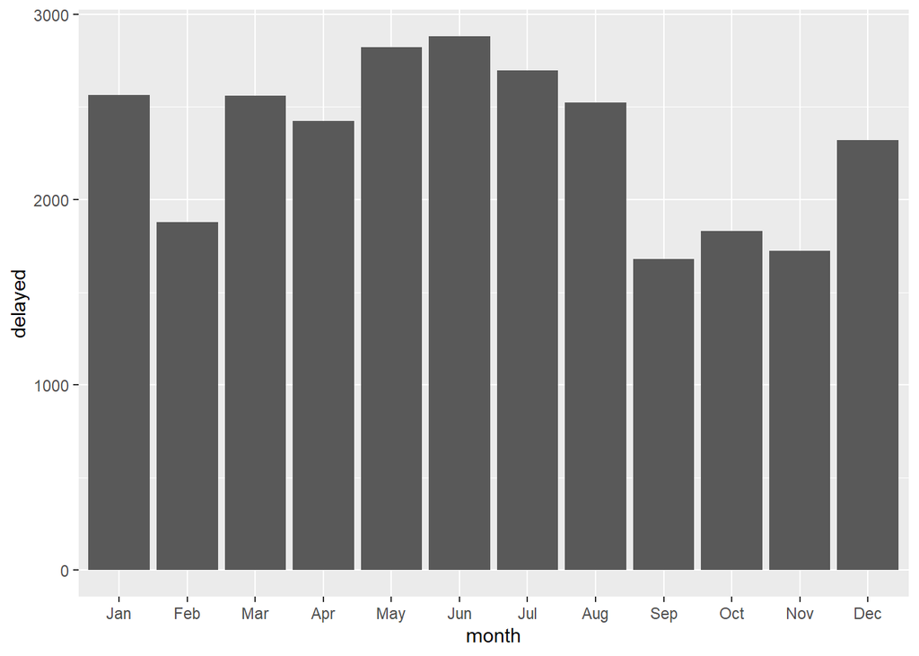

```r
# discrete number by month (delayed only)
flights_ewr %>%
  summarise(delayed = sum(delay_flag == "Yes"),
            .by = month) %>%
  ggplot(aes(x=month, y=delayed))+
  geom_col()
```

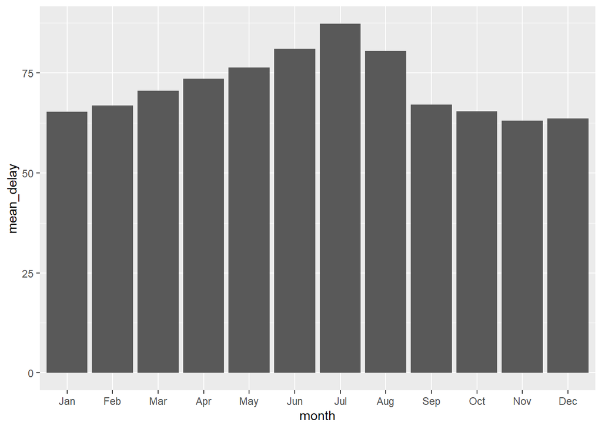

```r
# discrete mean delay by month (delayed only)
flights_ewr %>%
  filter(delay_flag == "Yes") %>%
  summarise(mean_delay = mean(dep_delay, na.rm = TRUE),
            .by = month) %>%
  ggplot(aes(x=month, y=mean_delay))+
  geom_col()
```

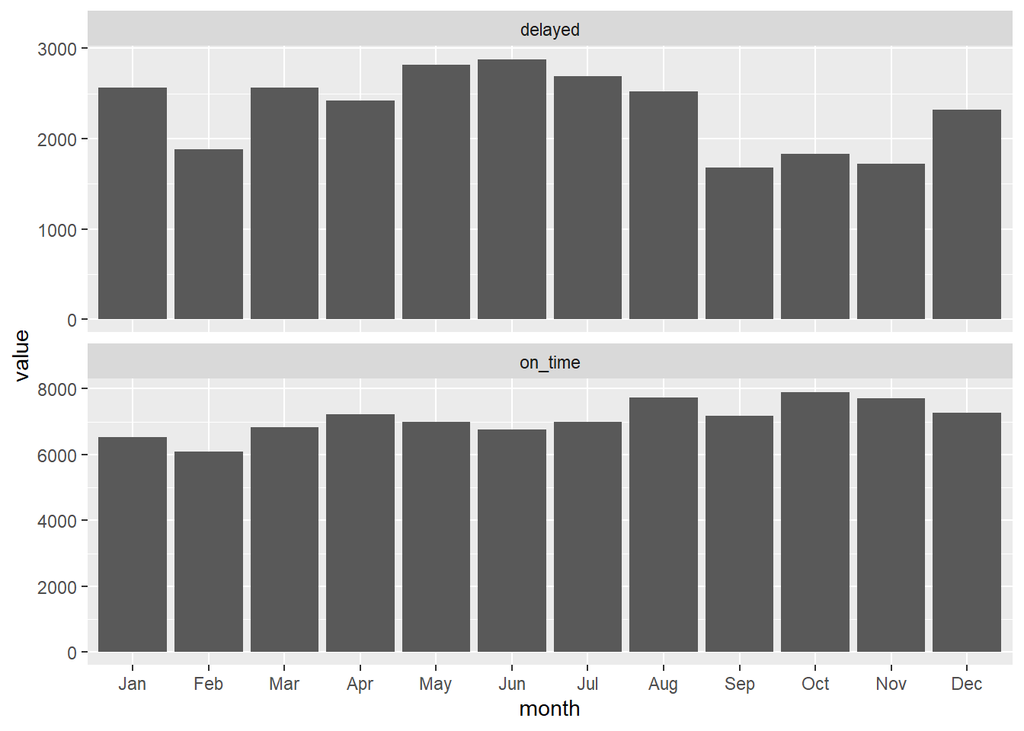

```r
# discrete number by month (delayed and on_time only)
flights_ewr %>%
  summarise(delayed = sum(delay_flag == "Yes"),
            on_time = sum(delay_flag == "No"),
            .by = month) %>%
  pivot_longer(cols = delayed:on_time,
               names_to = "status",
               values_to = "value") %>%
  ggplot(aes(x=month, y=value))+
  geom_col()+
  facet_wrap(~status, ncol = 1, scales = "free_y")
```

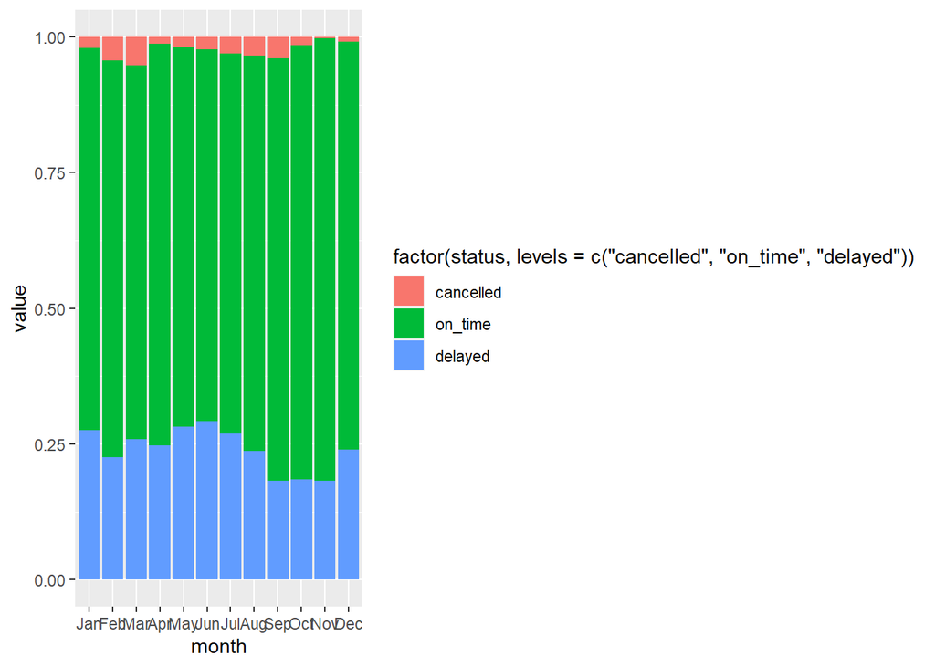

```r
# percentage by month
flights_ewr %>%
  summarise(on_time = sum(delay_flag == "No") / n(),
            delayed = sum(delay_flag == "Yes") / n(),
            cancelled = sum(delay_flag == "Cancelled") / n(),
            .by = month) %>%
  pivot_longer(cols = on_time:cancelled,
               names_to = "status",
               values_to = "value") %>%
  ggplot(aes(x = month, y = value,
             fill = factor(status, levels=c("cancelled", "on_time", "delayed"))))+
  geom_col()
```

### By day

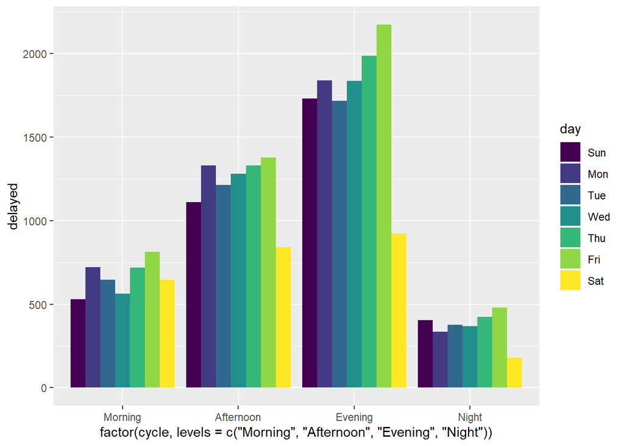

```r
# discrete number by day (delayed only)
flights_ewr %>%
  filter(delay_flag == "Yes") %>%
  summarise(delayed = n(),
            .by = c(day, cycle)) %>%
  ggplot(aes(x=factor(cycle,
                      levels=c("Morning", "Afternoon", "Evening", "Night")),
             y=delayed, fill=day))+
  geom_col(position = "dodge")
```

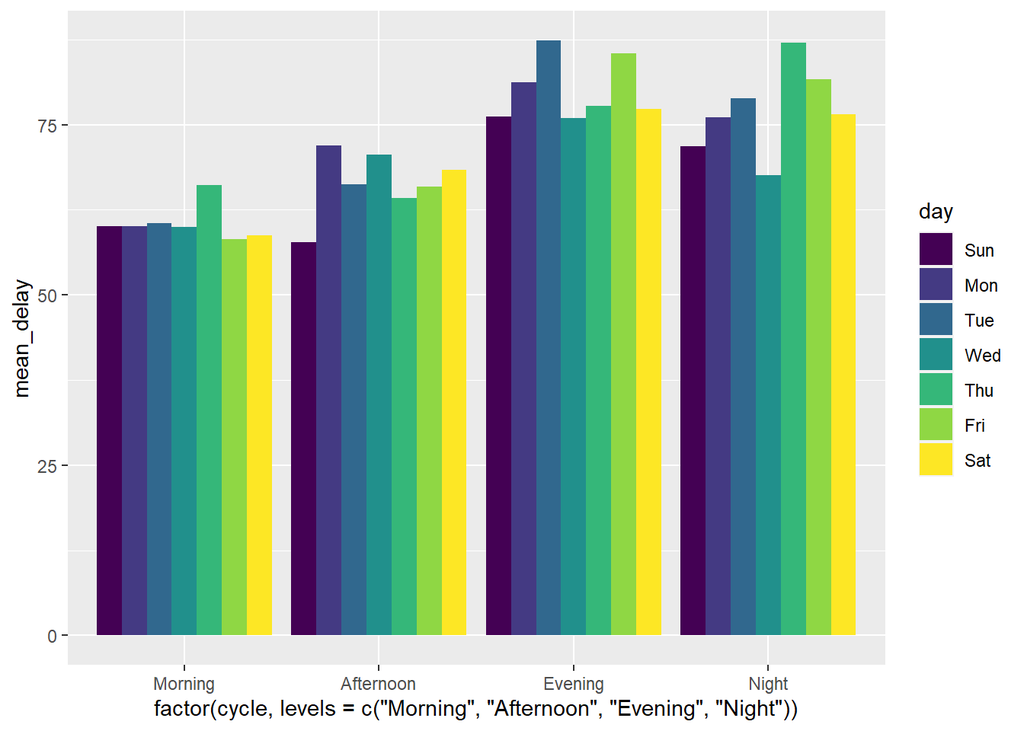

```r
# discrete mean delay by day (delayed only)
flights_ewr %>%
  filter(delay_flag == "Yes") %>%
  summarise(mean_delay = mean(dep_delay, na.rm = TRUE),
            .by = c(day, cycle)) %>%
  ggplot(aes(x=factor(cycle,
                      levels=c("Morning", "Afternoon", "Evening", "Night")),
             y=mean_delay, fill=day))+
  geom_col(position = "dodge")
```

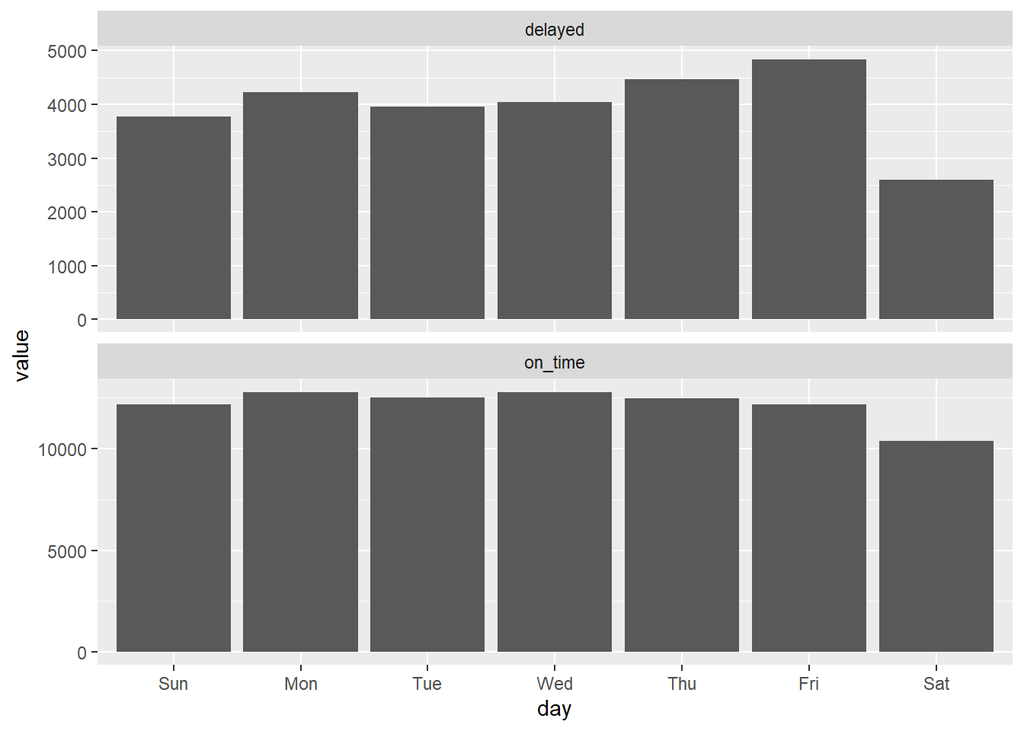

```r
# discrete number by day (delayed and on_time only)
flights_ewr %>%
  summarise(delayed = sum(delay_flag == "Yes"),
            on_time = sum(delay_flag == "No"),
            .by = day) %>%
  pivot_longer(cols = delayed:on_time,
               names_to = "status",
               values_to = "value") %>%
  ggplot(aes(x=day, y=value))+
  geom_col()+
  facet_wrap(~status, ncol = 1, scales = "free_y")
```

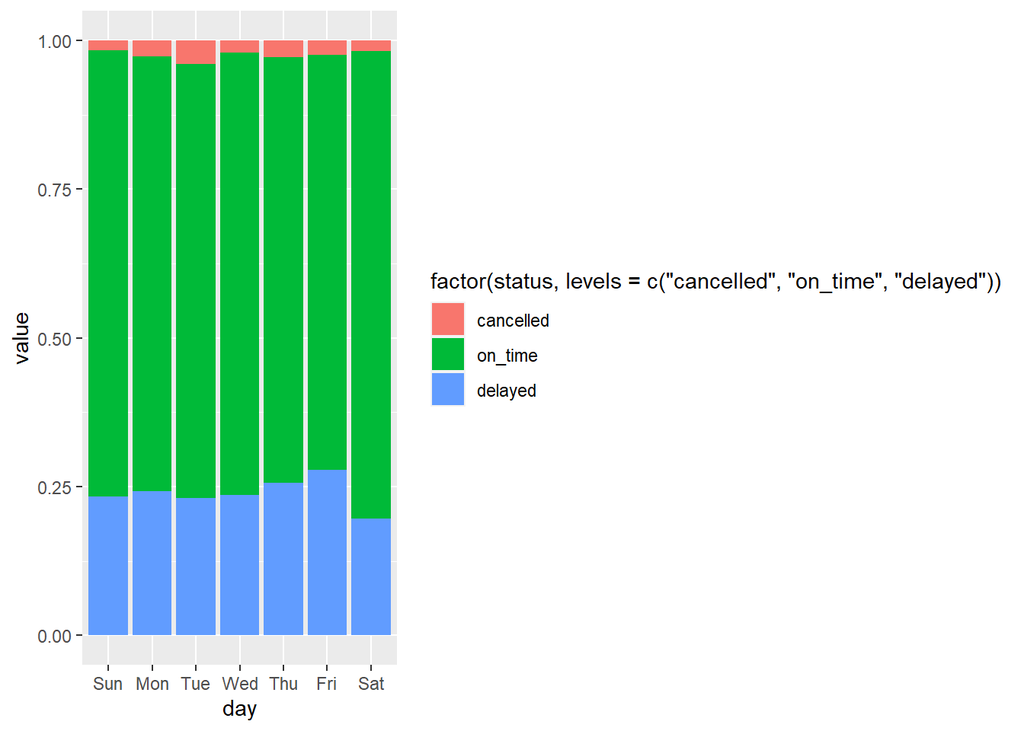

```r
# percentage by day
flights_ewr %>%
  summarise(on_time = sum(delay_flag == "No") / n(),
            delayed = sum(delay_flag == "Yes") / n(),
            cancelled = sum(delay_flag == "Cancelled") / n(),
            .by = day) %>%
  pivot_longer(cols = on_time:cancelled,
               names_to = "status",
               values_to = "value") %>%
  ggplot(aes(x = day, y = value,
             fill = factor(status, levels=c("cancelled", "on_time", "delayed"))))+
  geom_col()
```

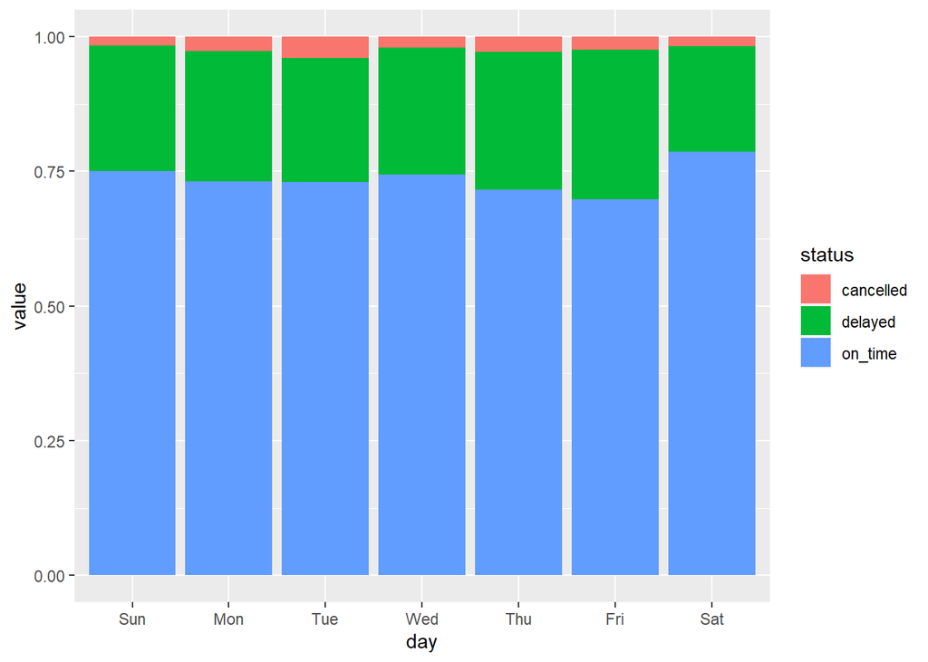

```r
# percentage by day of week
flights_ewr %>%
  summarise(on_time = sum(delay_flag == "No") / n(),
            delayed = sum(delay_flag == "Yes") / n(),
            cancelled = sum(delay_flag == "Cancelled") / n(),
            .by = day) %>%
  pivot_longer(cols = on_time:cancelled,
               names_to = "status",
               values_to = "value") %>%
  ggplot(aes(x=day, y=value, fill=status))+
  geom_col()
```

## All airports

### By month

```r
# actual number delayed by month
flights_high_level %>%
  summarise(delayed = sum(delay_flag == "Yes"),
            .by = c(month, origin)) %>%
  pivot_wider(names_from = origin, values_from = delayed) %>%
  arrange(month)
```

```
## # A tibble: 12 × 4
##    month   EWR   LGA   JFK
##    <ord> <int> <int> <int>
##  1 Jan    2564  1566  1622
##  2 Feb    1879  1072  1341
##  3 Mar    2562  2265  1860
##  4 Apr    2423  1725  2181
##  5 May    2821  1940  2488
##  6 Jun    2881  1868  2339
##  7 Jul    2696  2085  2400
##  8 Aug    2524  1768  2144
##  9 Sep    1678  1098  1142
## 10 Oct    1829  1509  1333
## 11 Nov    1722  1026   695
## 12 Dec    2321  1684  1467
```

```r
# percentage delayed by month
flights_high_level %>%
  summarise(delayed = sum(delay_flag == "Yes") / n(),
            .by = c(month, origin)) %>%
  pivot_wider(names_from = origin, values_from = delayed) %>%
  arrange(month)
```

```
## # A tibble: 12 × 4
##    month   EWR   LGA    JFK
##    <ord> <dbl> <dbl>  <dbl>
##  1 Jan   0.276 0.212 0.209
##  2 Feb   0.226 0.155 0.187
##  3 Mar   0.259 0.273 0.224
##  4 Apr   0.248 0.229 0.275
##  5 May   0.282 0.245 0.305
##  6 Jun   0.293 0.236 0.285
##  7 Jul   0.270 0.265 0.283
##  8 Aug   0.237 0.215 0.253
##  9 Sep   0.182 0.146 0.152
## 10 Oct   0.185 0.183 0.176
## 11 Nov   0.182 0.133 0.0968
## 12 Dec   0.240 0.218 0.190
```

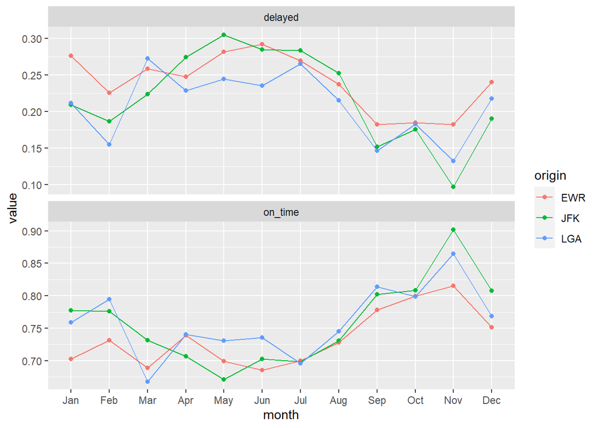

```r
# compare airports by month
flights_high_level %>%
  summarise(on_time = sum(delay_flag == "No") / n(),
            delayed = sum(delay_flag == "Yes") / n(),
            cancelled = sum(delay_flag == "Cancelled") / n(),
            .by = c(month, origin)) %>%
  pivot_longer(cols = on_time:cancelled,
               names_to = "status",
               values_to = "value") %>%
  filter(status != "cancelled") %>%
  ggplot(aes(x=month, y=value, colour=origin, group=origin))+
  geom_point()+
  geom_line()+
  facet_wrap(~status, ncol = 1, scales = "free_y")
```

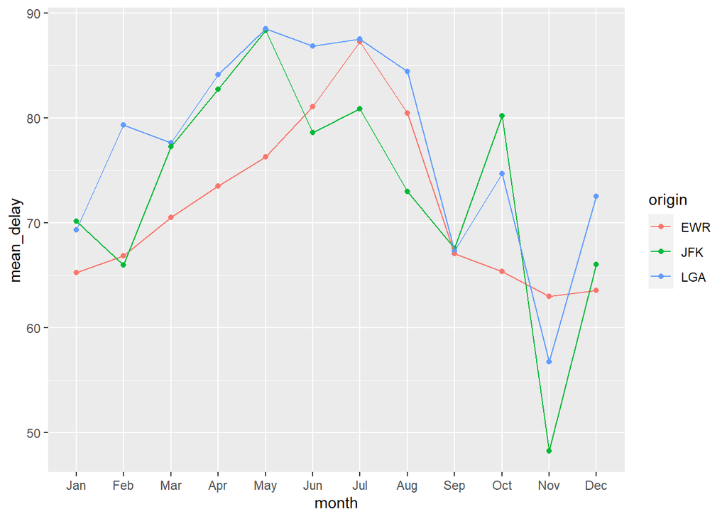

```r
# discrete mean delay by month (delayed only)
flights_high_level %>%
  filter(delay_flag == "Yes") %>%
  summarise(mean_delay = mean(dep_delay, na.rm = TRUE),
            .by = c(month, origin)) %>%
  ggplot(aes(x=month, y=mean_delay, colour=origin, group=origin))+
  geom_point()+
  geom_line()
```

### By day

```r
# actual number delayed by day
flights_high_level %>%
  summarise(delayed = sum(delay_flag == "Yes"),
            .by = c(day, origin)) %>%
  pivot_wider(names_from = origin, values_from = delayed)
```

```
## # A tibble: 7 × 4
##   day     EWR   LGA   JFK
##   <ord> <int> <int> <int>
## 1 Sun    3775  2059  3213
## 2 Mon    4229  3426  3105
## 3 Tue    3952  2998  2760
## 4 Wed    4047  2777  2403
## 5 Thu    4464  3400  3027
## 6 Fri    4842  3622  3623
## 7 Sat    2591  1324  2881
```

```r
# percentage delayed by day
flights_high_level %>%
  summarise(delayed = sum(delay_flag == "Yes") / n(),
            .by = c(day, origin)) %>%
  pivot_wider(names_from = origin, values_from = delayed)
```

```
## # A tibble: 7 × 4
##   day     EWR   LGA   JFK
##   <ord> <dbl> <dbl> <dbl>
## 1 Sun   0.233 0.169 0.230
## 2 Mon   0.242 0.236 0.223
## 3 Tue   0.231 0.211 0.209
## 4 Wed   0.236 0.193 0.179
## 5 Thu   0.256 0.234 0.217
## 6 Fri   0.278 0.249 0.260
## 7 Sat   0.196 0.148 0.238
```

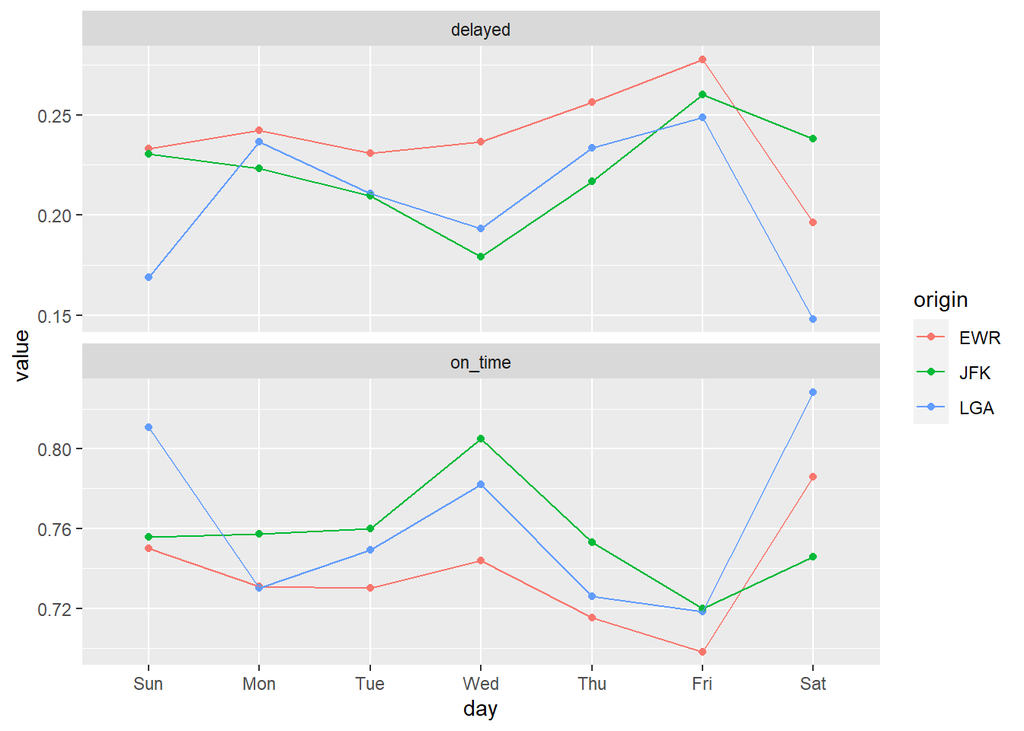

```r
# compare airports by day
flights_high_level %>%
  summarise(on_time = sum(delay_flag == "No") / n(),
            delayed = sum(delay_flag == "Yes") / n(),
            cancelled = sum(delay_flag == "Cancelled") / n(),
            .by = c(day, origin)) %>%
  pivot_longer(cols = on_time:cancelled,
               names_to = "status",
               values_to = "value") %>%
  filter(status != "cancelled") %>%
  ggplot(aes(x=day, y=value, colour=origin, group=origin))+
  geom_point()+
  geom_line()+
  facet_wrap(~status, ncol = 1, scales = "free_y")
```

# Statistical tests

### Proportion of flights delayed

Test whether the proportion of delayed flights during the holidays is significantly higher than the proportion of delayed flights outside the holiday period across the year at a significance level $\alpha = 0.05$.

$$H_0: \pi_{holiday\_delays} -
\pi_{not\_holiday\_delays} <= 0$$

$$H_a: \pi_{holiday\_delays} -
\pi_{not\_holiday\_delays} > 0$$

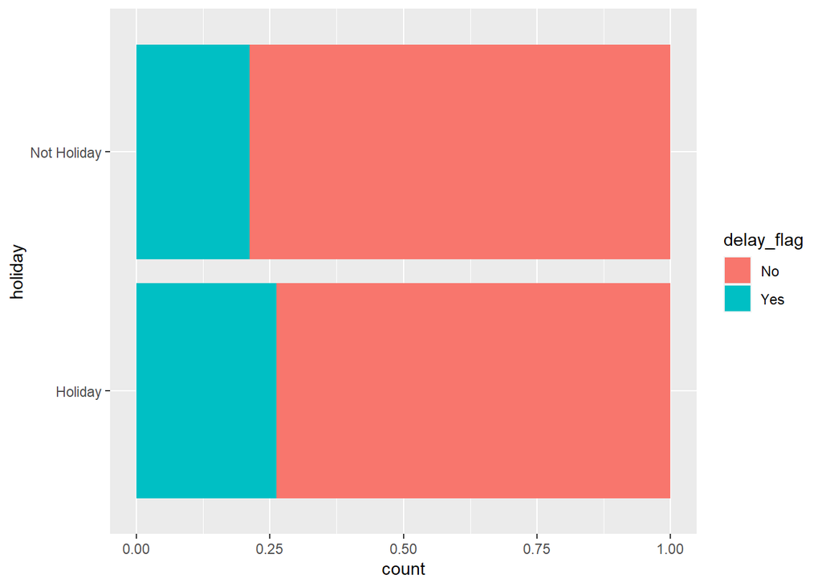

```r
ewr_holidays_prop <- flight_delays_df %>%
  filter(delay_flag %in% c("Yes", "No")) %>%
  mutate(holiday = case_when(
    between(as.Date(sch_departure), as.Date("2017-03-01"),as.Date("2017-03-31")) ~ "Holiday",
    between(as.Date(sch_departure), as.Date("2017-06-01"),as.Date("2017-08-31")) ~ "Holiday",
    between(as.Date(sch_departure), as.Date("2017-12-15"),as.Date("2017-12-31")) ~ "Holiday",
    .default = "Not Holiday")) %>%
    select(holiday, delay_flag)

ewr_holidays_prop %>%
  ggplot(aes(x = holiday, fill = delay_flag)) +
  geom_bar(position = "fill") +
  coord_flip()
```

```r
# calculate observed stat
observed_stat <- ewr_holidays_prop %>%
  specify(delay_flag ~ holiday, success = "Yes") %>%
  calculate(stat = "diff in props", order = c("Holiday", "Not Holiday"))
```

```r
# calculate null_distribution
null_distribution <- ewr_holidays_prop %>%
  specify(delay_flag ~ holiday, success = "Yes") %>%
  hypothesize(null = "independence") %>%
  generate(reps = 1000, type = "permute") %>%
  calculate(stat = "diff in props", order = c("Holiday", "Not Holiday"))
```

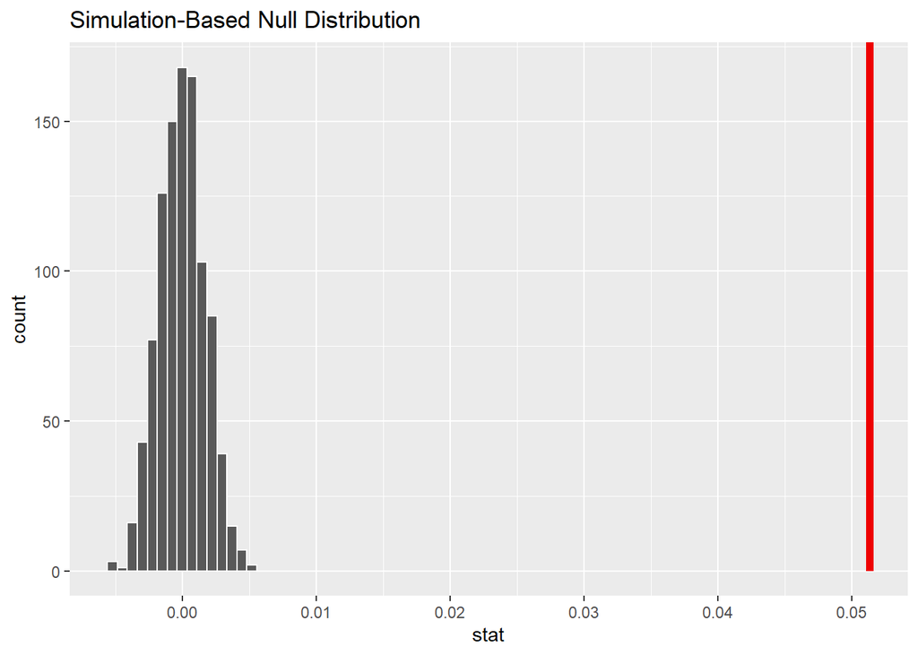

```r
# visualise the null distribution
null_distribution %>%
  visualise() +
  shade_p_value(obs_stat = observed_stat, direction = "right")
```

```r
# calculate the p-value
null_distribution %>%
  get_p_value(obs_stat = observed_stat, direction = "right")
```

```
## # A tibble: 1 × 1
##   p_value
##     <dbl>
## 1       0
```

There is strong evidence to reject $H_0$ and conclude that the proportion of delayed flights during the holidays is significantly higher than the proportion of delayed flights outside the holiday period across the year.

### Mean length of delayed flights

$$H_0: \mu_{holiday\_delays} -
\mu_{not\_holiday\_delays} <= 0$$

$$H_a: \mu_{holiday\_delays} -
\mu_{not\_holiday\_delays} > 0$$

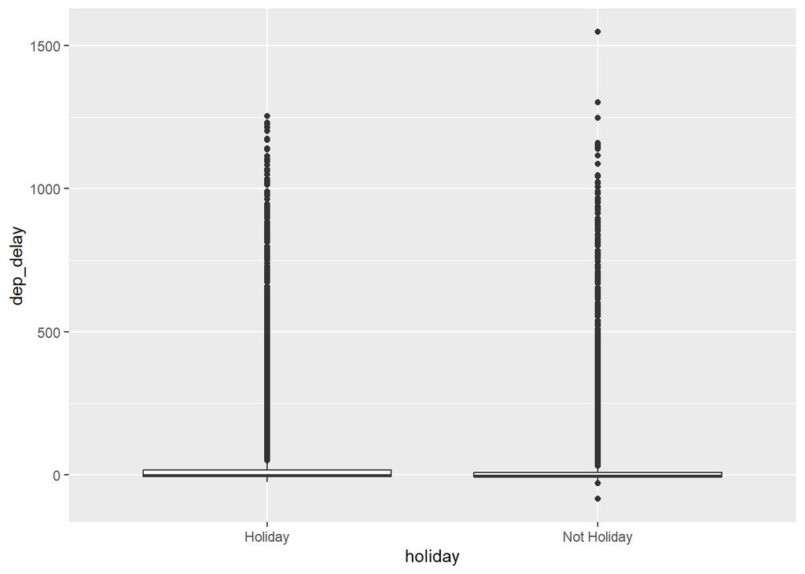

```r
ewr_holidays_mean<- flight_delays_df %>%
  filter(delay_flag %in% c("Yes", "No")) %>%
  mutate(holiday = case_when(
    between(as.Date(sch_departure), as.Date("2017-03-01"),as.Date("2017-03-31")) ~ "Holiday",
    between(as.Date(sch_departure), as.Date("2017-06-01"),as.Date("2017-08-31")) ~ "Holiday",
    between(as.Date(sch_departure), as.Date("2017-12-15"),as.Date("2017-12-31")) ~ "Holiday",
    .default = "Not Holiday")) %>%
    select(holiday, dep_delay)

ewr_holidays_mean %>%
  ggplot(aes(x = holiday, y = dep_delay)) +
  geom_boxplot()
```

```r
# calculate observed stat
observed_stat <- ewr_holidays_mean %>%
  specify(dep_delay ~ holiday) %>%
  calculate(stat = "diff in means", order = c("Holiday", "Not Holiday"))
```

```r
# calculate null_distribution
null_distribution <- ewr_holidays_mean %>%
  specify(dep_delay ~ holiday) %>%
  hypothesize(null = "independence") %>%
  generate(reps = 1000, type = "permute") %>%
  calculate(stat = "diff in means", order = c("Holiday", "Not Holiday"))
```

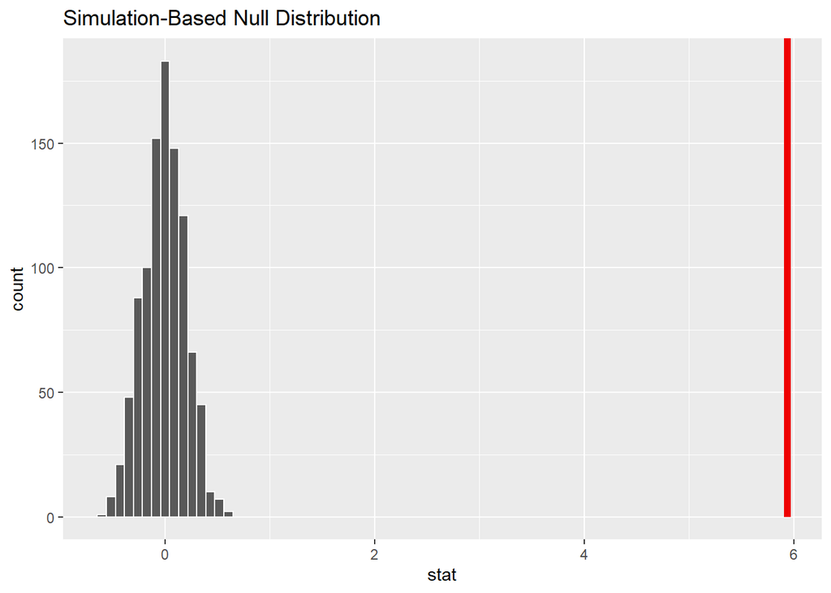

```r
# visualise the null distribution
null_distribution %>%
  visualise() +
  shade_p_value(obs_stat = observed_stat, direction = "right")
```

```r
# calculate the p-value
null_distribution %>%
  get_p_value(obs_stat = observed_stat, direction = "right")
```

```
## # A tibble: 1 × 1
##   p_value
##     <dbl>
## 1       0
```

## Compare airports

### Proportion of flights delayed

Test whether the proportion of delayed flights at EWR is significantly higher than the proportion of delayed flights at JFK and LGA (combined) across the year at a significance level $\alpha = 0.05$.

$$H_0: \pi_{newark\_delays} -
\pi_{other\_delays} <= 0$$

$$H_a: \pi_{newark\_delays} -
\pi_{other\_delays} > 0$$

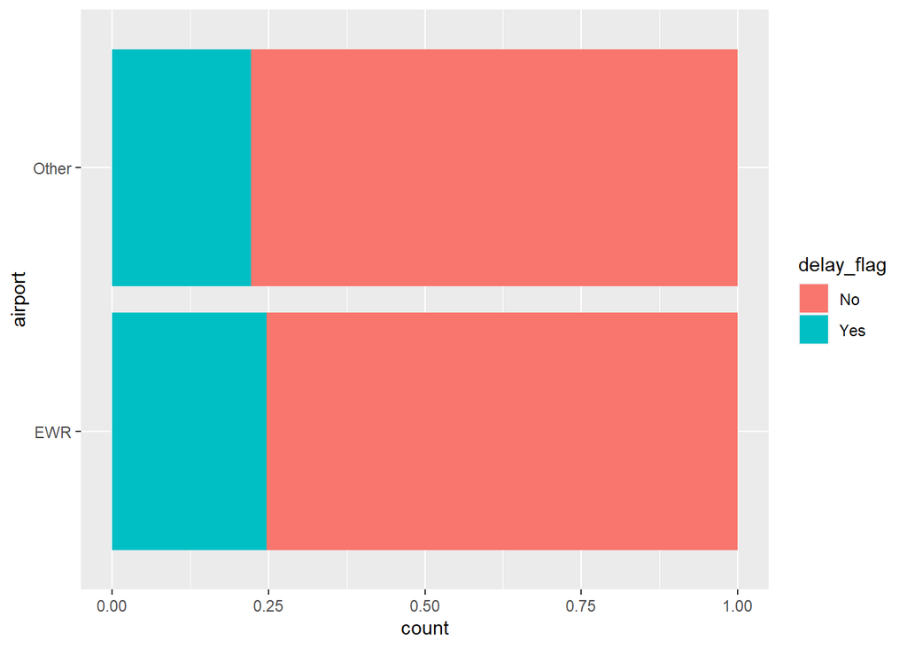

```r
airport_prop_diff <- flight_delays_df %>%
  filter(delay_flag %in% c("Yes", "No")) %>%
  mutate(airport = if_else(origin == "EWR", "EWR", "Other")) %>%
  select(airport, delay_flag)

airport_prop_diff %>%
  ggplot(aes(x = airport, fill = delay_flag)) +
  geom_bar(position = "fill") +
  coord_flip()
```

```r
# calculate observed stat
observed_stat <- airport_prop_diff %>%
  specify(delay_flag ~ airport, success = "Yes") %>%
  calculate(stat = "diff in props", order = c("EWR", "Other"))
```

```r
# calculate null_distribution
null_distribution <- airport_prop_diff %>%
  specify(delay_flag ~ airport, success = "Yes") %>%
  hypothesize(null = "independence") %>%
  generate(reps = 1000, type = "permute") %>%
  calculate(stat = "diff in props", order = c("EWR", "Other"))
```

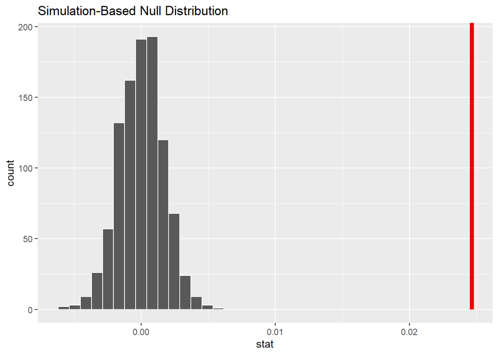

```r
# visualise the null distribution
null_distribution %>%
  visualise() +
  shade_p_value(obs_stat = observed_stat, direction = "right")
```

```r
# calculate the p-value
null_distribution %>%
  get_p_value(obs_stat = observed_stat, direction = "right")
```

```
## # A tibble: 1 × 1
##   p_value
##     <dbl>
## 1       0
```

There is strong evidence to reject $H_0$ and conclude that the proportion of delayed flights at EWR is significantly higher than the proportion of delayed flights at JFK and LGA (combined) across the year.

### Mean length of delayed flights

Test whether the mean length of flight delays at EWR is significantly higher than the mean length of flight delays at JFK and LGA (combined) across the year at a significance level $\alpha = 0.05$.

$$H_0: \mu_{newark\_delays} -
\mu_{other\_delays} <= 0$$

$$H_a: \mu_{newark\_delays} -
\mu_{other\_delays} > 0$$

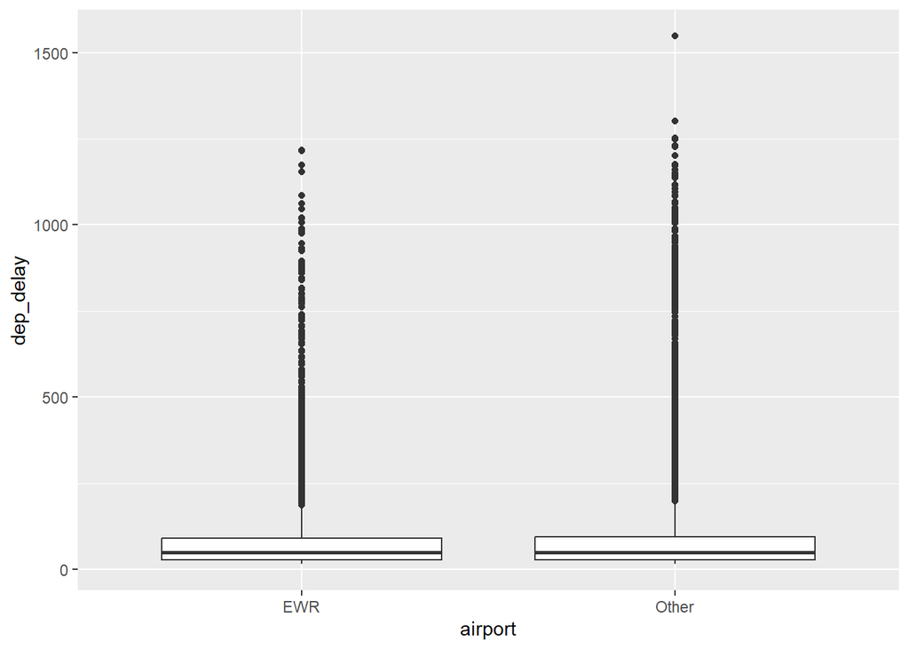

```r
airport_delay_diff <- flight_delays_df %>%
  filter(delay_flag == "Yes") %>%
  mutate(airport = if_else(origin == "EWR", "EWR", "Other")) %>%
  select(airport, dep_delay)

airport_delay_diff %>%
  ggplot(aes(x = airport, y = dep_delay)) +
  geom_boxplot()
```

```r
# calculate observed stat
observed_stat <- airport_delay_diff %>%
  specify(dep_delay ~ airport) %>%
  calculate(stat = "diff in means", order = c("EWR", "Other"))
```

```r
# calculate null_distribution
null_distribution <- airport_delay_diff %>%
  specify(dep_delay ~ airport) %>%
  hypothesize(null = "independence") %>%
  generate(reps = 1000, type = "permute") %>%
  calculate(stat = "diff in means", order = c("EWR", "Other"))
```

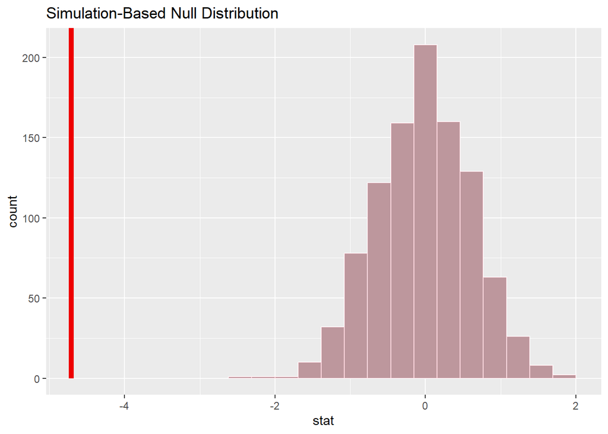

```r
# visualise the null distribution
null_distribution %>%
  visualise() +
  shade_p_value(obs_stat = observed_stat, direction = "right")
```

```r
# calculate the p-value
null_distribution %>%
  get_p_value(obs_stat = observed_stat, direction = "right")
```

```
## # A tibble: 1 × 1
##   p_value
##     <dbl>
## 1       1
```

The p-value is above $\alpha = 0.05$, therefore we fail to reject $H_0$: there is no significant evidence that he mean length of flight delays at EWR is significantly higher than the mean length of flight delays at JFK and LGA (combined) across the year.